# Introduction to MSanalyzeNOM

Robert B. Young

6/11/2020

## Introduction

This document demonstrates R functions in the **{MSanalyzeNOM}** package for analyzing the mass spectrometry (MS) data of natural organic matter (NOM) samples after formula assignment. It was specifically created to analyze MS data from NOM samples analyzed by Fourier transform ion cyclotron resonance (FTICR) MS at the [National High Magnetic Field Laboratory](https://nationalmaglab.org/user-facilities/icr) (MagLab) in Tallahassee, Florida, USA. The MSanalyzeNOM package generally assumes that the detected ions are singly-charged, based on literature describing the ESI-FTICR MS analysis of dissolved NOM (e.g., Stenson et al. 2002).

## Reading MS Data from the MagLab

The MSanalyzeNOM package uses the *get_sample_data()* function to read Excel files exported by PetroOrg©, software that was created at the MagLab for mass calibration, molecular formula assignment, visualization, and other purposes. The Excel file contains sheets with summary data, a sheet with mass spectrometry data for detected ions that could not be assigned molecular formulas (“no hits”), and numerous sheets containing mass spectrometry data for the assigned molecular formulas, which have been separated by heteroatom class (the number and identity of heteroatoms contained in the assigned molecular formulas). For example, $C_{6}H_{10}O_{5}$ and $C_{7}H_{12}O_{5}$ are part of the “O5” heteroatom class, and $C_{11}H_{9}NO_{6}S$ is part of the “N1 O6 S1” heteroatom class.

The *get_sample_data()* function returns a named list containing file and sample information, selected mass spectrometry parameters, mass spectrometry data related to the assigned molecular formulas, and mass spectrometry data related to the “no hits”. To facilitate the plotting of mass spectra, it combines the detected m/z’s and relative abundances from the “no hits” and assigned formulas into a list element named “all_detected_ions”.

```r
# sample_xcel contains the path and filename of a sample Excel file for a DOM sample. if no path and filename are given,
# R's file.choose() function will permit you to choose a file
DOM_sample <- get_sample_data(sample_xcel)
```

#### Types of Sample Info

The named list contains fields for the sample name, ionization method, and elements used for formula assignment. These fields are saved for use in later calculations. For example, the sample name can be used in plot titles, and the ionization method can be used to compute neutral masses for assigned formulas. If no ionization method is specified, the default value is “NegESI” because it is more commonly used for NOM analysis (Ohno et al. 2016).

```r
DOM_sample$sample_name
```

```
[1] "This_is_a_PetroOrg_Excel_file"
```

```r
DOM_sample$ion_technique
```

```
[1] "NegESI"
```

```r
DOM_sample$elements_used
```

```
[1] "C" "H" "N" "O" "S"
```

#### Changing the Sample Name

When the sample name is too detailed for a plot title, it can easily be changed.

```r
DOM_sample$sample_name <- "DOM Sample 1"
DOM_sample$sample_name
```

```
[1] "DOM Sample 1"
```

#### Types of MS Data for the Assigned Formulas

The mass spectrometry data for the assigned formulas includes the assigned chemical formula, its theoretical monoisotopic mass, the detected m/z, the mass error, the ion’s relative abundance, the ion’s percent abundance, and more. Much of this information, including the column names, is used by functions in the MSanalyzeNOM package to produce additional data and visualizations. When applicable, the function documentation will indicate the required column names.

```r
head(DOM_sample$assigned_formulas)
```

| class_element | class_hetero | chem_formula | theor_MI_mass | mz | theor_mz | ppm_error | rel_abund | DBE | C | H | N | O | S | perc_abund | DBEtoC | ModAI | HtoC | OtoC | NtoC | group_25perc | KMD_CH2_theor | z_CH2 | NOSC | mass_defect |
| --- | --- | --- | --- | --- | --- | --- | --- | --- | --- | --- | --- | --- | --- | --- | --- | --- | --- | --- | --- | --- | --- | --- | --- | --- |
| CHNO | N4 O4 | C9H10N4O4 | 238.07020 | 237.06294 | 237.06293 | -0.0506194710 | 0.075279750 | 7 | 9 | 10 | 4 | 4 | 0 | 0.0010446090 | 0.77777778 | 0.33333333 | 1.1111111 | 0.444444444 | 0.444444444 | Bottom 25% | 0.2018 | -1 | 1.11111111 | 0.07020447 |
| CHO | O1 | C15H6O1 | 202.04186 | 201.03459 | 201.03459 | -0.0099485368 | 0.075479696 | 13 | 15 | 6 | 0 | 1 | 0 | 0.0010473835 | 0.86666667 | 0.86206897 | 0.4000000 | 0.066666667 | 0.000000000 | Bottom 25% | 0.1899 | -9 | -0.26666667 | 0.04186447 |
| CHNO | N4 O3 | C16H24N4O3 | 320.18484 | 319.17761 | 319.17756 | -0.1441204056 | 0.075479696 | 7 | 16 | 24 | 4 | 3 | 0 | 0.0010473835 | 0.43750000 | 0.14285714 | 1.5000000 | 0.187500000 | 0.250000000 | Bottom 25% | 0.1788 | -3 | -0.37500000 | 0.18484047 |
| CHNO | N1 O3 | C18H25N1O3 | 303.18344 | 302.17618 | 302.17617 | -0.0430212617 | 0.075579669 | 7 | 18 | 25 | 1 | 3 | 0 | 0.0010487708 | 0.38888889 | 0.29032258 | 1.3888889 | 0.166666667 | 0.055555556 | Bottom 25% | 0.1612 | -6 | -0.88888889 | 0.18344347 |
| CHNO | N1 O7 | C22H25N1O7 | 415.16310 | 414.15587 | 414.15583 | -0.1062402054 | 0.075579669 | 11 | 22 | 25 | 1 | 7 | 0 | 0.0010487708 | 0.50000000 | 0.37142857 | 1.1363636 | 0.318181818 | 0.045454545 | Bottom 25% | 0.3066 | -6 | -0.36363636 | 0.16310247 |
| CHNO | N2 O7 | C8H10N2O7 | 246.04880 | 245.04155 | 245.04152 | -0.1061044658 | 0.075579669 | 5 | 8 | 10 | 2 | 7 | 0 | 0.0010487708 | 0.62500000 | 0.00000000 | 1.2500000 | 0.875000000 | 0.250000000 | Bottom 25% | 0.2321 | -7 | 1.25000000 | 0.04880047 |

#### Additional Details

Additional details for the *get_sample_data()* function can be examined by typing *“?get_sample_data”* in the R console.

## Examining and Visualizing the NOM Data

#### Composition by Elemental Class

The MSanalyzeNOM package uses the *get_CHNOS_element_class()* function to assign elemental classes (e.g., CHO or CHNOS) for the default element list.

```r
DOM_sample$assigned_formulas <- DOM_sample$assigned_formulas %>%
  get_CHNOS_element_class()
```

Then, the NOM samples can be summarized and visualized as a function of their elemental content.

```r
DOM_sample$assigned_formulas %>%
  compute_perc_abund() %>%
  dplyr::group_by(class_element) %>%
  dplyr::summarize(`num formulas` = dplyr::n(),
                   `% abund` = sum(perc_abund))
```

| class_element | num formulas | % abund |
| --- | --- | --- |
| CHO | 2224 | 71.4012277 |
| CHNO | 3296 | 23.0012954 |
| CHOS | 416 | 5.2034859 |
| CHNOS | 183 | 0.3939910 |

#### Mass Spectrum

The mass spectrum plots the relative abundances of all detected ions, assigned and unassigned, and gives the most comprehensive view of what could be ionized in the sample. The MSanalyzeNOM package uses the *plot_mass_spectrum()* function to plot a sample’s mass spectrum.

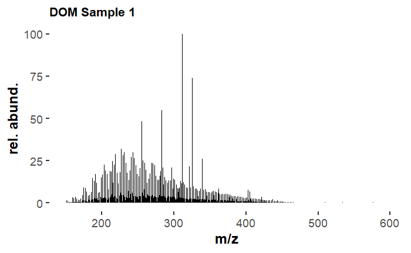

```r
plot_mass_spectrum(DOM_sample$all_detected_ions,
                   plot_title = DOM_sample$sample_name)
```

The *plot_mass_spectrum()* function contains optional parameters (min_x and max_x) to zoom in on a particular range in the mass spectrum. The m/z values were centroided in PetroOrg©, so the abundances and spacing of the detected ions are visible, but their mass resolution is not. This can be examined in profile mode using PetroOrg© or [Predator Analysis](https://nationalmaglab.org/user-facilities/icr/icr-software) software.

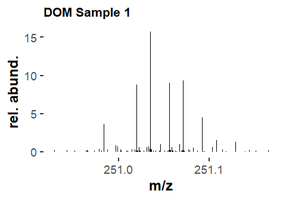

```r
plot_mass_spectrum(DOM_sample$all_detected_ions,
                   plot_title = DOM_sample$sample_name,
                   min_x = 250.9, max_x = 251.2)
```

```r
DOM_sample$assigned_formulas  %>%
  dplyr::select(class_hetero, chem_formula, mz, ppm_error, rel_abund) %>%
  dplyr::arrange(dplyr::desc(rel_abund)) %>%
  head(n = 8)
```

| class_hetero | chem_formula | mz | ppm_error | rel_abund |
| --- | --- | --- | --- | --- |
| O3 S1 | C17H28O3S1 | 311.16857 | 0.221744711 | 100.000000 |
| O3 S1 | C18H30O3S1 | 325.18421 | 0.242939166 | 73.927214 |
| O2 | C18H36O2 | 283.26425 | 0.014121090 | 54.939721 |
| O2 | C16H32O2 | 255.23295 | 0.015671958 | 48.428173 |
| O4 | C13H8O4 | 227.03499 | -0.035236860 | 31.966101 |
| O5 | C12H8O5 | 231.02990 | -0.012985332 | 29.966639 |
| O5 | C13H8O5 | 243.02990 | -0.012344160 | 29.954042 |
| O5 | C11H8O5 | 219.02992 | -0.105008496 | 28.780358 |

Importantly, the numbers of detected ions and assigned formulas are sensitive to suppression from high abundance ions because the vast majority of detected ions occur at relatively low abundances. This can make comparisons between NOM samples challenging.

#### Double Bond Equivalents (DBE)

The number of double bond equivalents (DBE) is the estimated number of rings and double bonds in a chemical compound. The basic calculation is:

> $$DBE = 1 + \frac{\sum_{i=1}^{n}N_i\left(V_i - 2\right)}{2}$$
> **where:**
> $N_i$ = number of element $i$
> $V_i$ = valence of element $i$

A simpler calculation for several common elements is:

> $$DBE = 1 - \frac{a}{2} + \frac{c}{2} + d$$
> **where:**
> $a$ = number of atoms with a valence of 1 (H, F, Cl, Br)
> $b$ = number of atoms with a valency of 2 (O, S)
> $c$ = number of atoms with a valency of 3 (N, P)
> $d$ = number of atoms with a valency of 4 (C, Si)

The basic DBE calculation has been criticized because it fails to take [multiple valence states](https://fiehnlab.ucdavis.edu/projects/seven-golden-rules/ring-double-bonds) into account, and because rings and double bonds can also be formed with heteroatoms in DOM (Gonsior et al. 2009).

The MSanalyzeNOM package imports DBE values from PetroOrg©, but they can also be computed using the *compute_DBE()* function. The following code shows that they produce the same values.

```r
reanalyzed_DOM_sample <- compute_DBE(DOM_sample$assigned_formulas, DOM_sample$elements_used)
identical(DOM_sample$assigned_formulas$DBE, reanalyzed_DOM_sample$DBE)
```

```
[1] TRUE
```

```r
rm(reanalyzed_DOM_sample)
```

#### DBE/C Ratios

The DBE/C ratio estimates double bond density and aromaticity by normalizing DBE to the number of carbons. Under this approach, DBE/C $\ge$ 0.5 suggests an aromatic structure, and DBE/C $\ge$ 0.67 suggests a condensed aromatic structure. The MSanalyzeNOM package uses the *compute_DBEtoC()* function to calculate this ratio.

```r
DOM_sample$assigned_formulas <- compute_DBEtoC(DOM_sample$assigned_formulas)
```

| chem_formula | DBE | C | DBEtoC |
| --- | --- | --- | --- |
| C9H10N4O4 | 7 | 9 | 0.77777778 |
| C15H6O1 | 13 | 15 | 0.86666667 |
| C16H24N4O3 | 7 | 16 | 0.43750000 |
| C18H25N1O3 | 7 | 18 | 0.38888889 |
| C22H25N1O7 | 11 | 22 | 0.50000000 |
| C8H10N2O7 | 5 | 8 | 0.62500000 |

#### Aromaticity/Modified Aromaticity Index

The introduction of an O atom to a molecular formula does not change the number of DBEs, but reduces the number of C=C double bonds if C=O double bonds are present. Similarly, the introduction of an N atom (and corresponding H atom) reduces the number of C=C double bonds if C=N double bonds are present.

The aromaticity index (AI) created by Koch & Dittmar (2006) assumes that heteroatoms form double bonds, and offers a more conservative estimate of aromaticity. Similar to the DBE/C ratio, AI $\ge$ 0.5 suggests an aromatic structure, and AI $\ge$ 0.67 suggests a condensed aromatic structure.

Because NMR spectroscopy frequently shows that dissolved organic matter (DOM) has high carboxyl content, the modified aromaticity index (ModAI) treats one-half of the oxygen as carboxyl oxygen, rather than carbonyl oxygen. This increases the number of compounds that qualify as aromatic or condensed aromatic structures, but is still more conservative than DBE/C ratios.

The *compute_arom_index()* function produces separate column names for the aromaticity index or modified aromaticity index. The desired index is specified with the “AItype” argument (default = “ModAI”). Like Koch & Dittmar (2006), the aromaticity index calculations are based on common heteroatoms (N, O, P, S).

```r
DOM_sample$assigned_formulas <- compute_arom_index(DOM_sample$assigned_formulas,
                                                   elements = DOM_sample$elements_used,
                                                   AItype = "AI")

DOM_sample$assigned_formulas <- compute_arom_index(DOM_sample$assigned_formulas,
                                                   elements = DOM_sample$elements_used,
                                                   AItype = "ModAI")
```

| chem_formula | DBE | C | DBEtoC | AI | ModAI |
| --- | --- | --- | --- | --- | --- |
| C9H10N4O4 | 7 | 9 | 0.77777778 | 0.00000000 | 0.33333333 |
| C15H6O1 | 13 | 15 | 0.86666667 | 0.85714286 | 0.86206897 |
| C16H24N4O3 | 7 | 16 | 0.43750000 | 0.00000000 | 0.14285714 |
| C18H25N1O3 | 7 | 18 | 0.38888889 | 0.21428571 | 0.29032258 |
| C22H25N1O7 | 11 | 22 | 0.50000000 | 0.21428571 | 0.37142857 |
| C8H10N2O7 | 5 | 8 | 0.62500000 | 0.00000000 | 0.00000000 |

#### Useful Elemental Ratios

The MSanalyzeNOM package uses the *compute_elemental_ratios()* function to compute elemental ratios. The column name is derived from the numerator and denominator that are supplied. “C” is the default denominator used for van Krevelen diagrams, but different elemental ratios can be used for other purposes. For example, Zark et al. 2017 have developed a method for estimating numbers of carboxyl groups from O/H ratios.

```r
DOM_sample$assigned_formulas <- DOM_sample$assigned_formulas %>%
  compute_elemental_ratios(num = "H") %>%
  compute_elemental_ratios(num = "O") %>%
  compute_elemental_ratios(num = "N") %>%
  compute_elemental_ratios(num = "O", denom = "H")
```

| class_element | chem_formula | HtoC | OtoC | NtoC | group_25perc | KMD_CH2_theor | z_CH2 | NOSC | mass_defect | AI | OtoH |
| --- | --- | --- | --- | --- | --- | --- | --- | --- | --- | --- | --- |
| CHNO | C9H10N4O4 | 1.1111111 | 0.444444444 | 0.444444444 | Bottom 25% | 0.2018 | -1 | 1.11111111 | 0.07020447 | 0.00000000 | 0.40000000 |
| CHO | C15H6O1 | 0.4000000 | 0.066666667 | 0.000000000 | Bottom 25% | 0.1899 | -9 | -0.26666667 | 0.04186447 | 0.85714286 | 0.16666667 |
| CHNO | C16H24N4O3 | 1.5000000 | 0.187500000 | 0.250000000 | Bottom 25% | 0.1788 | -3 | -0.37500000 | 0.18484047 | 0.00000000 | 0.12500000 |
| CHNO | C18H25N1O3 | 1.3888889 | 0.166666667 | 0.055555556 | Bottom 25% | 0.1612 | -6 | -0.88888889 | 0.18344347 | 0.21428571 | 0.12000000 |
| CHNO | C22H25N1O7 | 1.1363636 | 0.318181818 | 0.045454545 | Bottom 25% | 0.3066 | -6 | -0.36363636 | 0.16310247 | 0.21428571 | 0.28000000 |
| CHNO | C8H10N2O7 | 1.2500000 | 0.875000000 | 0.250000000 | Bottom 25% | 0.2321 | -7 | 1.25000000 | 0.04880047 | 0.00000000 | 0.70000000 |

#### van Krevelen Diagrams (H/C vs. O/C)

A traditional van Krevelen diagram plots O/C vs. H/C ratios to reflect O and H densities in the sample. In general, low H/C ratios reflect the presence of rings and double bonds, and high H/C ratios reflect their absence. Similarly, high O/C ratios reflect the presence of hydroxyl, carboxyl and other oxygen functional groups, and low O/C ratios reflect their absence. To support interpretation, the area above the horizontal line at H/C = 1.5 is designated as the aliphatic region (D’Andrilli et al. 2015, Lv et al. 2017), and the area below the diagonal line from H/C = 1.1 is designated as the aromatic region, based on the modified aromaticity index.

1. *Flat Diagram (No Information on Abundance)*

The following plot, created by the *plot_VK_flat()* function, shows the distribution of the assigned formulas as a function of their H/C and O/C ratios, but contains no information about the intensities of the detected ions. The darker areas are where the highest number of formulas are plotted.

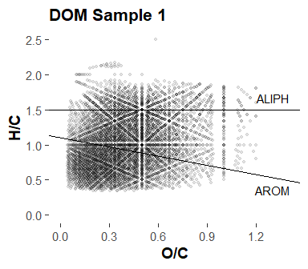

```r
plot_VK_flat(DOM_sample$assigned_formulas, plot_title = DOM_sample$sample_name)
```

The *plot_VK_flat()* function can separate the assigned formulas by elemental class, or another factor variable, using the *panel* and *var_panel* arguments.

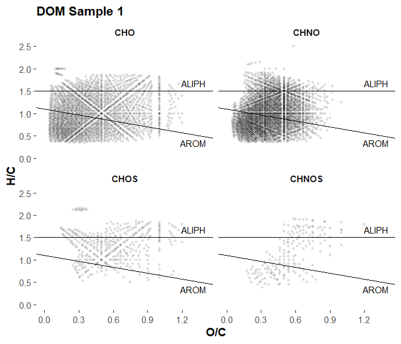

```r
plot_VK_flat(DOM_sample$assigned_formulas, plot_title = DOM_sample$sample_name, panel = TRUE, var_panel = "class_element")
```

Just as DBE/C and the aromaticity indexes don’t perfectly predict aromaticity, the lines on the van Krevelen diagram are approximations of aliphatic and aromatic content. When all of the points with a modified aromaticity index equal to 0.5 are plotted, they do not form a straight line.

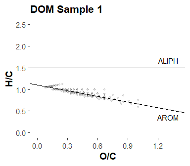

```r
DOM_sample$assigned_formulas %>%
  dplyr::filter(ModAI == 0.5) %>%
  plot_VK_flat(plot_title = DOM_sample$sample_name)
```

2. *Color Gradient Based on Relative Abundances*

The *plot_VK_gradient()* function creates a van Krevelen diagram colored with a gradient based on their relative abundances. However, when a few assigned formulas are detected at substantially higher abundances, coloring the van Krevelen diagram in this way may not adequately resolve the NOM components.

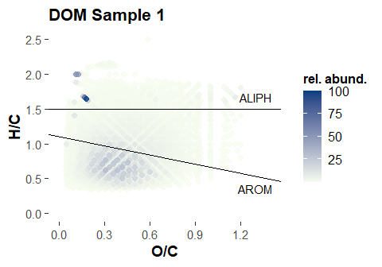

```r
plot_VK_gradient(DOM_sample$assigned_formulas, var = "rel_abund",
                 plot_title = DOM_sample$sample_name)
```

If the highly abundant formulas are known (e.g., linear alkylbenzene sulfonate surfactants), the van Krevelen diagram can be re-plotted without them, as long as the figure is appropriately annotated. After removing the LAS surfactants and stearic and palmitic acids referenced above, the van Krevelen diagram does offer better resolution.

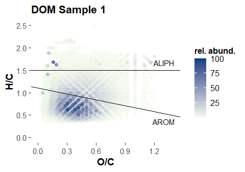

```r
# assigned_formulas and new_assigned_formulas should be segregated if saving
# DOM_sample
DOM_sample$new_assigned_formulas <- DOM_sample$assigned_formulas  %>%
  dplyr::filter(!chem_formula %in%
                c("C17H28O3S1", "C18H30O3S1", "C18H36O2", "C16H32O2")) %>%
  # normalize rel_abund to new highest value
  dplyr::mutate(rel_abund = rel_abund / max(rel_abund) * 100)
plot_VK_gradient(DOM_sample$new_assigned_formulas, var = "rel_abund",
                 plot_title = DOM_sample$sample_name)
```

3. *Grouped by %Contribution to Abundance*

Another alternative for increasing resolution is to group assigned formulas by their percent contribution to total assigned abundance, and then plot the grouped formulas in a van Krevelen diagram. For example, the assigned formulas can be ordered by their percent relative abundances, and grouped by whether they comprise the top 25%“,”second 25%“,”third 25%“, or”bottom 25%" of the sample’s total percent abundance. Because there are only four levels, and the high abundance laboratory contaminants are usually grouped with abundant NOM components, the distribution of NOM components is better resolved. The *plot_VK_25perc_groups()* function creates a van Krevelen diagram that is colored on this basis.

```r
DOM_sample$assigned_formulas <- DOM_sample$assigned_formulas %>%
  get_25perc_groups()
```

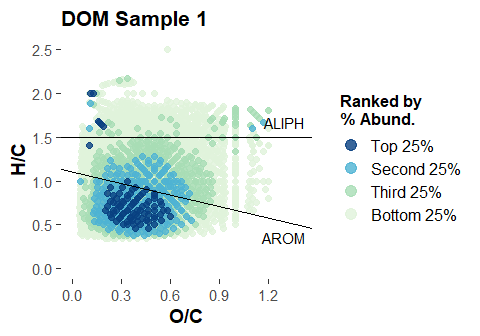

```r
plot_VK_25perc_groups(DOM_sample$assigned_formulas, plot_title = DOM_sample$sample_name)
```

This plot can be supplemented with data on the number of formulas in each category. In the sample plotted above, 1.5% of the formulas make up the first 25% of abundance, and 80.7% of the formulas make up the bottom 25%.

```r
temp <- DOM_sample$assigned_formulas  %>%
  dplyr::group_by(group_25perc) %>%
  dplyr::rename(group = group_25perc) %>%
  dplyr::summarize(`formulas` = dplyr::n())
temp
```

| group | formulas |
| --- | --- |
| Top 25% | 89 |
| Second 25% | 275 |
| Third 25% | 818 |
| Bottom 25% | 4937 |

Finally, like the flat VK diagram, the *plot_VK_25perc_groups()* function can separate the assigned formulas by elemental class using the *panel* and *var_panel* arguments.

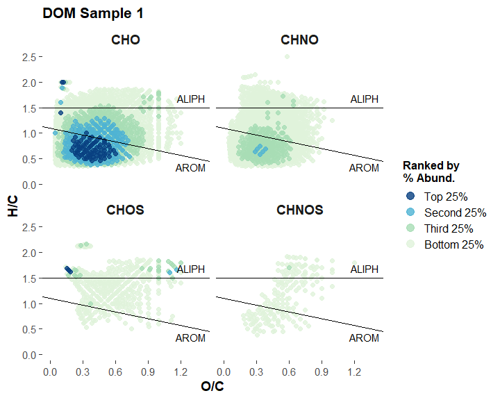

```r
plot_VK_25perc_groups(DOM_sample$assigned_formulas,
                      plot_title = DOM_sample$sample_name, panel = TRUE, var_panel = "class_element")
```

#### Kendrick Mass Defects and z* values

In mass spectrometry, mass defect is commonly defined as the difference between a compound’s exact mass and its nominal mass. For example, the theoretical monoisotopic mass of $C_{11}H_{16}O$ is 164.12012u, and it’s mass defect is 0.12012u. The mass defect of $^{12}C$ is zero by definition (12.00000u - 12u). Other elemental isotopes have negative mass defects (e.g., $^{16}O$ = 15.99491u - 16u and $^{35}Cl$ = 34.96885u - 35u), or positive mass defects (e.g., $^{1}H$ = 1.00783u - 1u). As a result, each chemical formula has a relatively unique monoisotopic mass that can be detected with accurate mass measurement. Mass defects permit accurate formula assignment and confirmation from measured accurate masses, and facilitate the search for compounds of interest through mass defect filtering (Sleno 2011).

Ordinarily, the members of a homologous series with a $-CH_2-$ repeating unit (e.g., LAS surfactants with different alkyl chain lengths) differ by a mass of 14.01565u, and a mass defect of 0.01565u. Kendrick masses (Kendrick 1963, Hughey et al. 2001) are computed by multiplying every accurate mass by 14u/14.01565u, so that members of the same $-CH_2-$ homologous series differ by a mass of 14.0000, and have identical Kendrick mass defects. This logic can also be applied to other repeating units like $CO_2$ and $H_2O$.

The MSanalyzeNOM package uses the *compute_KMD_CH2()* function to compute Kendrick mass defects (KMD) for measured or theoretical masses where $-CH_2-$ (14.01565u) is the repeating unit. The theoretical Kendrick mass defects will be identical, subject to rounding errors, and the measured Kendrick mass defects will reflect additional measurement errors. The *compute_KMD_CH2()* function produces separate column names for measured and theoretical Kendrick mass defects, and desired index is specified with the “KMDtype” argument (default = “theor”). In addition, the number of digits can be specified to limit or explore rounding errors in the KMD calculation.

Because it is possible for different homologous series to have very similar KMDs, z* values can be used to separate the compounds further by their membership in nominal mass series. For example, the members of a homologous series with a $-CH_2-$ repeating unit differ from each other by a nominal mass of 14u. This means that there are 13 nominal masses between any two members of a $-CH_2-$ homologous series. The *compute_KMD_CH2()* function also produces 14 unique z* values to identify the 14 different nominal mass series that are possible for members of $-CH_2-$ homologous series.

```r
DOM_sample$assigned_formulas <- DOM_sample$assigned_formulas %>%
  compute_KMD_CH2(KMDtype = "meas", num_digits = 5) %>%
  compute_KMD_CH2(KMDtype = "theor")
```

```r
DOM_sample$assigned_formulas %>%
  dplyr::arrange(class_element, O, KMD_CH2_theor, mz) %>%
  dplyr::select(chem_formula, mz, theor_mz, z_CH2, KMD_CH2_meas, KMD_CH2_theor) %>%
  head()
```

| chem_formula | mz | theor_mz | z_CH2 | KMD_CH2_meas | KMD_CH2_theor |
| --- | --- | --- | --- | --- | --- |
| C11H16O1 | 163.11287 | 163.11284 | -5 | 0.06926 | 0.0693 |
| C12H18O1 | 177.12852 | 177.12849 | -5 | 0.06926 | 0.0693 |
| C13H20O1 | 191.14414 | 191.14414 | -5 | 0.06929 | 0.0693 |
| C14H22O1 | 205.15979 | 205.15979 | -5 | 0.06929 | 0.0693 |
| C15H24O1 | 219.17543 | 219.17544 | -5 | 0.06930 | 0.0693 |
| C16H26O1 | 233.19108 | 233.19109 | -5 | 0.06930 | 0.0693 |

As an example, the linear alkylbenzyl sulfonate (LAS) surfactants have a $-CH_2-$ repeating unit, and a theoretical Kendrick mass defect equal to 0.1788, but the N4 O3 heteroatom class also contains a $-CH_2-$ homologous series with a theoretical Kendrick mass defect equal to 0.1788, when rounding is taken into account. Because they are members of different 14u nominal mass series, the LAS surfactants can be separated from the N4 O3 heteroatom class by their Z* values (or by their heteroatom class because formula assignments have already been made).

```r
DOM_sample$assigned_formulas %>%
  dplyr::filter(KMD_CH2_theor == 0.1788) %>%
  dplyr::select(class_hetero, chem_formula, mz, rel_abund,
                z_CH2, KMD_CH2_meas, KMD_CH2_theor) %>%
  dplyr::arrange(z_CH2, dplyr::desc(rel_abund))
```

| class_hetero | chem_formula | mz | rel_abund | z_CH2 | KMD_CH2_meas | KMD_CH2_theor |
| --- | --- | --- | --- | --- | --- | --- |
| O3 S1 | C17H28O3S1 | 311.16857 | 100.000000000 | -11 | 0.17888 | 0.1788 |
| O3 S1 | C18H30O3S1 | 325.18421 | 73.927213580 | -11 | 0.17889 | 0.1788 |
| O3 S1 | C19H32O3S1 | 339.19996 | 26.187255628 | -11 | 0.17879 | 0.1788 |
| O3 S1 | C16H26O3S1 | 297.15298 | 20.767513539 | -11 | 0.17882 | 0.1788 |
| O3 S1 | C20H34O3S1 | 353.21560 | 0.453078122 | -11 | 0.17880 | 0.1788 |
| O3 S1 | C15H24O3S1 | 283.13739 | 0.168054793 | -11 | 0.17876 | 0.1788 |
| O3 S1 | C21H36O3S1 | 367.23130 | 0.112469746 | -11 | 0.17875 | 0.1788 |
| N4 O3 | C12H16N4O3 | 263.11497 | 0.191548473 | -3 | 0.17883 | 0.1788 |
| N4 O3 | C11H14N4O3 | 249.09938 | 0.181151270 | -3 | 0.17877 | 0.1788 |
| N4 O3 | C13H18N4O3 | 277.13065 | 0.175552776 | -3 | 0.17880 | 0.1788 |

[output cut: 5 more lines]

The MSanalyzeNOM package uses the *remove_common_contaminants()* function to remove LAS surfactants and stearic and palmitic acids from the assigned formulas to improve the visualization of less abundant NOM components, and the *remove_common_contaminants()* function identifies the LAS surfactant series using the “KMD_CH2_theor” and “z_CH2” values.

```r
DOM_sample$new_assigned_formulas <- DOM_sample$assigned_formulas  %>%
  remove_common_contaminants()
```

```r
DOM_sample$assigned_formulas  %>%
  dplyr::anti_join(DOM_sample$new_assigned_formulas, by = "chem_formula") %>%
  dplyr::select(class_hetero, chem_formula, mz, rel_abund,
                z_CH2, KMD_CH2_meas, KMD_CH2_theor) %>%
  dplyr::arrange(class_hetero, mz)
```

| class_hetero | chem_formula | mz | rel_abund | z_CH2 | KMD_CH2_meas | KMD_CH2_theor |
| --- | --- | --- | --- | --- | --- | --- |
| O2 | C16H32O2 | 255.23295 | 48.42817282 | -11 | 0.05205 | 0.0520 |
| O2 | C18H36O2 | 283.26425 | 54.93972121 | -11 | 0.05205 | 0.0520 |
| O3 S1 | C15H24O3S1 | 283.13739 | 0.16805479 | -11 | 0.17876 | 0.1788 |
| O3 S1 | C16H26O3S1 | 297.15298 | 20.76751354 | -11 | 0.17882 | 0.1788 |
| O3 S1 | C17H28O3S1 | 311.16857 | 100.00000000 | -11 | 0.17888 | 0.1788 |
| O3 S1 | C18H30O3S1 | 325.18421 | 73.92721358 | -11 | 0.17889 | 0.1788 |
| O3 S1 | C19H32O3S1 | 339.19996 | 26.18725563 | -11 | 0.17879 | 0.1788 |
| O3 S1 | C20H34O3S1 | 353.21560 | 0.45307812 | -11 | 0.17880 | 0.1788 |
| O3 S1 | C21H36O3S1 | 367.23130 | 0.11246975 | -11 | 0.17875 | 0.1788 |

As indicated above, any data that excludes the common contaminants should be appropriately annotated or discussed, and the edited and unedited data should be kept apart. Importantly, removing the contaminants does not remove their influence on the other detected ions and assigned formulas, which can be reduced in number due to ion suppression from the high abundance contaminants.

#### Average Oxidation State of Carbon

The average oxidation state of carbon (AvgOSC), or nominal oxidation state of carbon (NOSC), can be used to demonstrate the extent of oxidation in an NOM sample (Kroll et al. 2011), or to illustrate its thermodynamic favorability for oxidative degradation (Boye et al. 2017). The *compute_AvgOSC()* function computes the average oxidation state of carbon based on the following formula (Kroll et al. 2011, Riedel et al. 2012., and Lavonen et al. 2013):

> $$AvgOSC = -\sum_{i=1}^{n}OS_i\frac{n_i}{n_C}$$
> **where:**
> $OS_i$ = oxidation state of non-carbon element $i$
> $n_i$ = number of non-carbon element $i$
> $n_C$ = number of carbon atoms

A simpler calculation for several comment elements is:

> $$- \frac{h − 3n - 2o - 2s}{c}$$
> **where:**
> $c$ = number of carbon atoms
> $h$ = number of hydrogen atoms
> $n$ = number of nitrogen atoms
> $o$ = number of oxygen atoms $s$ = number of sulfur atoms

The calculation is currently limited to the default element list, and intentionally excludes P, which has several common oxidation states (i.e., -3, 3, and 5). It assumes that has an oxidation state of -2 (e.g., thiol), but +4 (sulfonate) is also common.

```r
DOM_sample$new_assigned_formulas <- compute_AvgOSC(DOM_sample$new_assigned_formulas,
                                               elements = DOM_sample$elements_used)
```

```r
DOM_sample$new_assigned_formulas %>%
  dplyr::arrange(class_element, O, mz) %>%
  dplyr::select(chem_formula, AvgOSC) %>%
  head(n = 8)
```

| chem_formula | AvgOSC |
| --- | --- |
| C11H8O1 | -0.54545455 |
| C11H10O1 | -0.72727273 |
| C11H12O1 | -0.90909091 |
| C11H14O1 | -1.09090909 |
| C11H16O1 | -1.27272727 |
| C12H6O1 | -0.33333333 |
| C12H8O1 | -0.50000000 |
| C12H10O1 | -0.66666667 |

#### Kroll Diagram

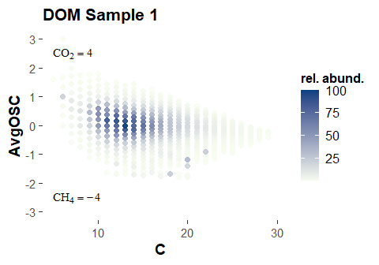

```r
plot_Kroll_gradient(DOM_sample$new_assigned_formulas, var = "rel_abund",
                    plot_title = DOM_sample$sample_name)
```

As above, the plot_Kroll functions can separate the assigned formulas by elemental class using the *panel* and *var_panel* arguments.

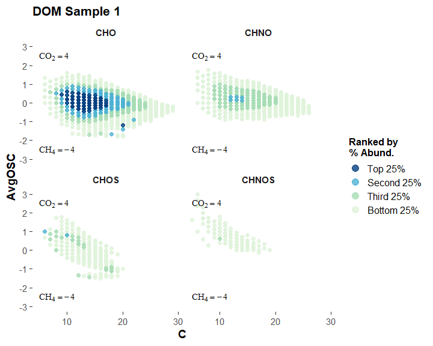

```r
plot_Kroll_25perc_groups(DOM_sample$new_assigned_formulas, plot_title = DOM_sample$sample_name, panel = TRUE,
                         var_panel = "class_element")
```

## Mass Defect

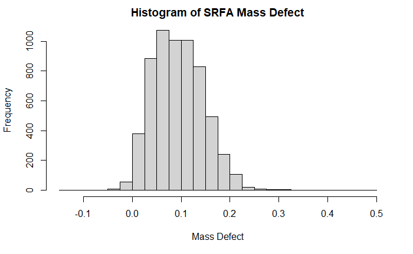

```r
mass_defect <- DOM_sample$assigned_formulas$theor_MI_mass - round(DOM_sample$assigned_formulas$theor_MI_mass,
                                                                  digits = 0)

hist(mass_defect,
     breaks = seq(-0.15, 0.5, by = 0.025),
     main = "Histogram of SRFA Mass Defect",
     xlab = "Mass Defect")
```

## Reproducible Data Analysis

An R markdown notebook or R programming script should be saved with the “raw” FTICR MS data (e.g., the Excel file exported by PetroOrg©) from any project to facilitate reproducible analysis of the data. The named list created by the *get_sample_data()* function, and supplemented by the functions in the MSanalyzeNOM package (in this example, “DOM_sample”), can be stored as a separate R object to avoid reprocessing the “raw” FTICR MS data.

## Future Work

Additional functions for FTICR MS data analysis and visualization will continue to be added, and new R markdown notebooks will be created to document their use.